# Practice work 2” - Xu Feiran - 21.M09

Xu Feiran

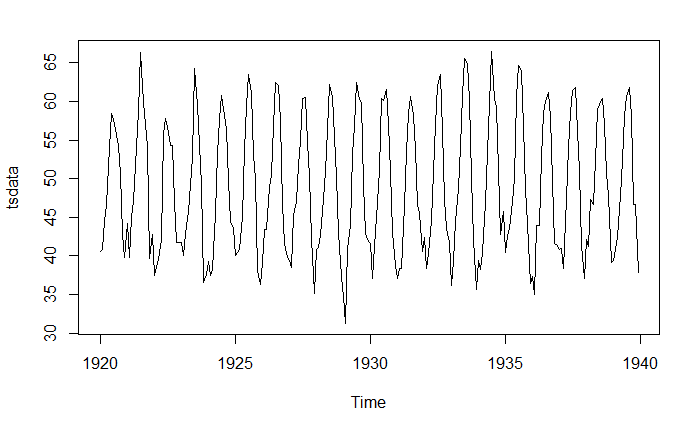

```r
szstock<-read.csv("./Datasets-master/monthly-mean-temp.csv")
MyData <- szstock$Temperature
tsdata <- ts(MyData, start =c(1920,1),frequency = 12)
plot.ts(tsdata)
```

Mean monthly air temperature (Deg. F) Nottingham Castle 1920-1939

Source: Time Series Data Library (citing: O.D. Anderson (1976))

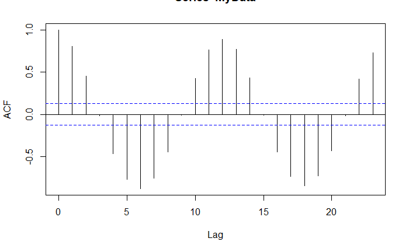

```r
MyData.acf <- acf(MyData)
```

```r
MyData.acf
```

```
Autocorrelations of series ‘MyData’, by lag

     0      1      2      3      4      5      6      7      8      9     10     11     12     13     14     15     16     17     18     19     20     21     22     23
 1.000  0.808  0.452 -0.018 -0.464 -0.770 -0.876 -0.756 -0.445 -0.010  0.429  0.765  0.884  0.770  0.435 -0.011 -0.441 -0.734 -0.844 -0.726 -0.431 -0.015  0.420  0.732
```

Autocorrelations of series ‘MyData’, by lag

[output not shown]

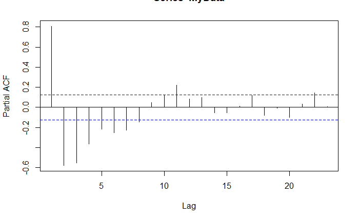

```r
MyData.pacf<-pacf(MyData)
```

```r
MyData.pacf
```

```
Partial autocorrelations of series ‘MyData’, by lag

     1      2      3      4      5      6      7      8      9     10     11     12     13     14     15     16     17     18     19     20     21     22     23
 0.808 -0.577 -0.552 -0.364 -0.215 -0.250 -0.224 -0.145  0.050  0.122  0.223  0.084  0.099 -0.055 -0.056  0.012  0.117 -0.078 -0.009 -0.098  0.035  0.145  0.007
```

Using diff function in R library forecast to create the difference series.

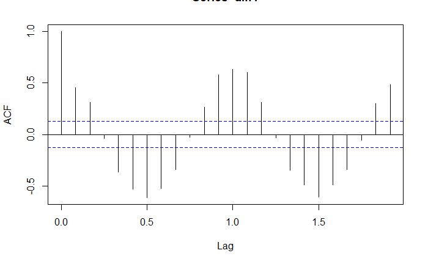

```r
diff1 <- diff(tsdata,lag = 1)
acf(diff1)
```

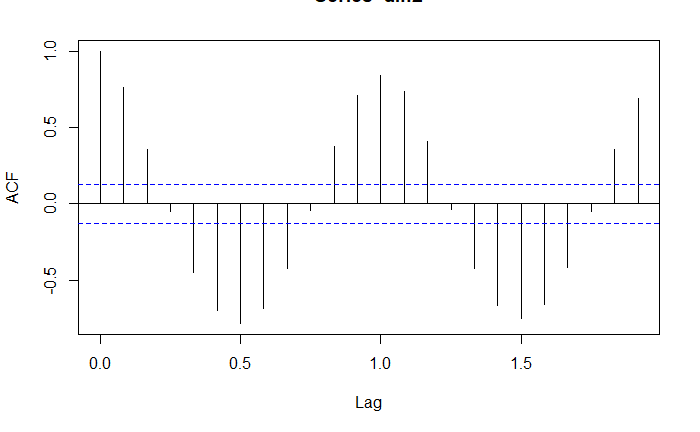

```r
diff2 <- diff(tsdata,lag = 2)
acf(diff2)
```

ADF test. H0: There exist the unit root.(not stationary series) H1: There doesn’t exist the unit root.(stationary series)

```r
library(tseries)
adf.test(tsdata)
```

```
    Augmented Dickey-Fuller Test

data:  tsdata
Dickey-Fuller = -13, Lag order = 6, p-value = 0.01
alternative hypothesis: stationary
```

```r
adf.test(diff1[-1])
```

```
    Augmented Dickey-Fuller Test

data:  diff1[-1]
Dickey-Fuller = -13.933, Lag order = 6, p-value = 0.01
alternative hypothesis: stationary
```

```r
adf.test(diff2[-2])
```

```
    Augmented Dickey-Fuller Test

data:  diff2[-2]
Dickey-Fuller = -14.031, Lag order = 6, p-value = 0.01
alternative hypothesis: stationary
```

This result show that we shoud reject the null hypothesis, which means the process is stationary.

We can use ndiffs function to find the order.

```r
library(forecast)
ndiffs(tsdata)
```

```
[1] 0
```

The result show us the order of stationary is 0 . As stated above, this time series is inherently stable.

```r
fit_model <- Arima(diff1,order = c(3,0,2))
fit_model
```

```
Series: diff1
ARIMA(3,0,2) with non-zero mean

Coefficients:
         ar1      ar2      ar3      ma1     ma2    mean
      1.3337  -0.3335  -0.3643  -1.7428  0.7778  0.0002
s.e.  0.0661   0.1117   0.0650   0.0390  0.0417  0.0181

sigma^2 estimated as 8.273:  log likelihood=-591.92
AIC=1197.84   AICc=1198.33   BIC=1222.18
```

```
    Ljung-Box test

data:  Residuals from ARIMA(3,0,2) with non-zero mean
Q* = 83.242, df = 18, p-value = 2.307e-10

Model df: 6.   Total lags used: 24
```

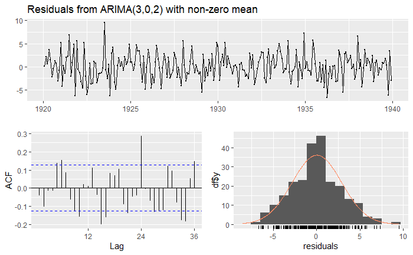

```r
checkresiduals(fit_model)
```

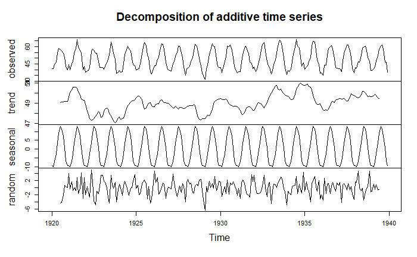

```r
plot(decompose(tsdata,type = "additive"))
```

I tried to use function decompose to find the seasonal component, and we can easily saw there has seasonal component in my time series, and the seasonal cycle is equal to 12. And here is the Seasonal Difference.

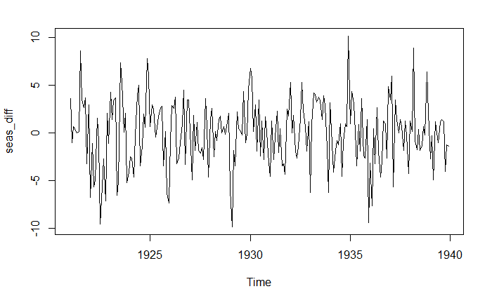

```r
seas_diff <- diff(tsdata, lag = 12)
plot(seas_diff)
```

```r
seas_diff_fit <- auto.arima(tsdata,seasonal = T)
seas_diff_fit
```

```
Series: tsdata
ARIMA(1,0,2)(1,1,2)[12] with drift

Coefficients:
         ar1     ma1     ma2     sar1     sma1     sma2  drift
      0.1565  0.0921  0.1114  -0.5254  -0.5021  -0.2326  0.004
s.e.  0.3647  0.3600  0.1135   0.1928   0.2087   0.1894  0.004

sigma^2 estimated as 5.205:  log likelihood=-516.21
AIC=1048.42   AICc=1049.08   BIC=1075.86
```

```
    Ljung-Box test

data:  Residuals from ARIMA(1,0,2)(1,1,2)[12] with drift
Q* = 17.926, df = 17, p-value = 0.3935

Model df: 7.   Total lags used: 24
```

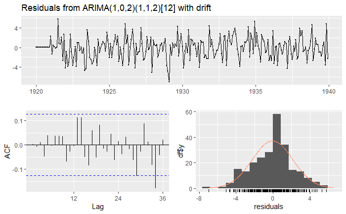

```r
checkresiduals(seas_diff_fit)
```

```r
seas_diff_fit.residual <- residuals(seas_diff_fit)
shapiro.test(seas_diff_fit.residual)
```

```
    Shapiro-Wilk normality test

data:  seas_diff_fit.residual
W = 0.9924, p-value = 0.2543
```

The p-value=0.2543 is greater than 0.05, that mean the H0 can not be rejected, so the residuals is normality.

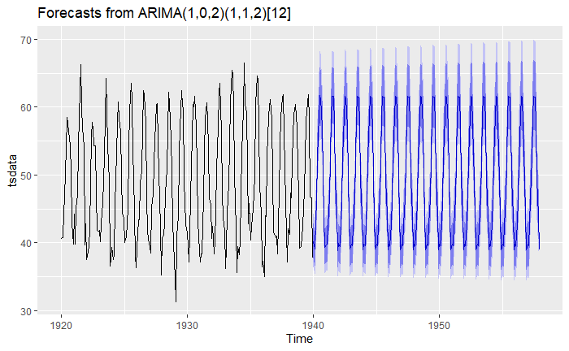

```r
  force_best <- forecast(Arima(tsdata,order=c(1,0,2),seasonal=c(1,1,2),lambda=0),h=216)
  force_intuition <- forecast(Arima(tsdata,order=c(2,0,2),seasonal=c(2,2,2),lambda=0),h=216)
  autoplot(force_best)
```

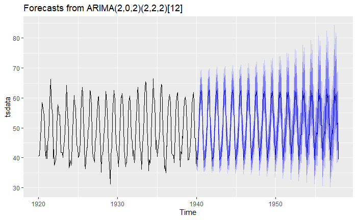

```r
  autoplot(force_intuition)
```

```r
summary(force_best)
```

```
Forecast method: ARIMA(1,0,2)(1,1,2)[12]

Model Information:
Series: tsdata
ARIMA(1,0,2)(1,1,2)[12]
Box Cox transformation: lambda= 0

Coefficients:
         ar1     ma1     ma2     sar1     sma1     sma2
      0.0957  0.1543  0.1347  -0.5334  -0.5079  -0.2230
s.e.  0.3597  0.3543  0.1093   0.1746   0.1909   0.1748

sigma^2 estimated as 0.002524:  log likelihood=353.2
AIC=-692.41   AICc=-691.9   BIC=-668.4

Error measures:
                  ME     RMSE      MAE          MPE     MAPE      MASE        ACF1
Training set 0.12794 2.197483 1.719495 -0.003441257 3.678136 0.6378863 0.008818547

Forecasts:
```

|  | Point Forecast | Lo 80 | Hi 80 | Lo 95 | Hi 95 |
| --- | --- | --- | --- | --- | --- |
| Jan 1940 | 40.20586 | 37.69857 | 42.87990 | 36.43522 | 44.36672 |
| Feb 1940 | 39.08098 | 36.57131 | 41.76287 | 35.30868 | 43.25630 |
| Mar 1940 | 43.10105 | 40.30170 | 46.09484 | 38.89419 | 47.76294 |
| Apr 1940 | 46.31372 | 43.30541 | 49.53102 | 41.79283 | 51.32366 |
| May 1940 | 52.53460 | 49.12220 | 56.18405 | 47.40645 | 58.21748 |
| Jun 1940 | 58.89013 | 55.06491 | 62.98108 | 53.14159 | 65.26052 |
| Jul 1940 | 61.68303 | 57.67640 | 65.96800 | 55.66186 | 68.35554 |
| Aug 1940 | 61.29453 | 57.31313 | 65.55250 | 55.31128 | 67.92500 |
| Sep 1940 | 57.08210 | 53.37432 | 61.04745 | 51.51005 | 63.25690 |
| Oct 1940 | 50.07378 | 46.82123 | 53.55228 | 45.18585 | 55.49047 |

[output cut: 206 more lines]

```r
summary(force_intuition)
```

```
Forecast method: ARIMA(2,0,2)(2,2,2)[12]

Model Information:
Series: tsdata
ARIMA(2,0,2)(2,2,2)[12]
Box Cox transformation: lambda= 0

Coefficients:
         ar1      ar2      ma1     ma2     sar1    sar2     sma1    sma2
      0.3246  -0.1344  -0.0467  0.1846  -0.0656  0.2504  -1.9570  0.9994
s.e.  1.0343   0.4608   1.0301  0.2521   0.0791  0.0818   0.5309  0.5422

sigma^2 estimated as 0.002528:  log likelihood=300.05
AIC=-582.1   AICc=-581.23   BIC=-551.73

Error measures:
                    ME     RMSE      MAE       MPE     MAPE      MASE       ACF1
Training set 0.2126706 2.124374 1.649093 0.3716462 3.519524 0.6117689 0.00803251

Forecasts:
```

|  | Point Forecast | Lo 80 | Hi 80 | Lo 95 | Hi 95 |
| --- | --- | --- | --- | --- | --- |
| Jan 1940 | 40.05138 | 37.43865 | 42.84644 | 36.12528 | 44.40417 |
| Feb 1940 | 39.42600 | 36.75998 | 42.28537 | 35.42245 | 43.88204 |
| Mar 1940 | 43.72369 | 40.74109 | 46.92465 | 39.24546 | 48.71293 |
| Apr 1940 | 46.80248 | 43.60976 | 50.22894 | 42.00877 | 52.14321 |
| May 1940 | 52.53292 | 48.94887 | 56.37939 | 47.15166 | 58.52832 |
| Jun 1940 | 59.93029 | 55.84149 | 64.31848 | 53.79117 | 66.77005 |
| Jul 1940 | 61.74781 | 57.53500 | 66.26908 | 55.42251 | 68.79501 |
| Aug 1940 | 62.47038 | 58.20828 | 67.04456 | 56.07106 | 69.60005 |
| Sep 1940 | 58.17712 | 54.20793 | 62.43695 | 52.21759 | 64.81681 |
| Oct 1940 | 49.87816 | 46.47517 | 53.53032 | 44.76876 | 55.57069 |

[output cut: 206 more lines]

Based on this result, we can see that both models predict well, but the first model has a smaller AIC.

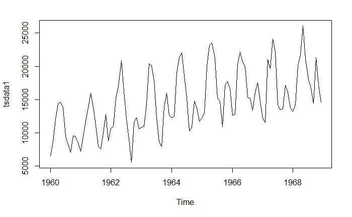

```r
car_sale<-read.csv("./Datasets-master/monthly-car-sales.csv")
MyData1 <- car_sale$Sales
tsdata1 <- ts(MyData1, start =c(1960,1),frequency = 12)
plot.ts(tsdata1)
```

Monthly car sales receive seasonal influences and are seasonal in nature and increase from year to year.

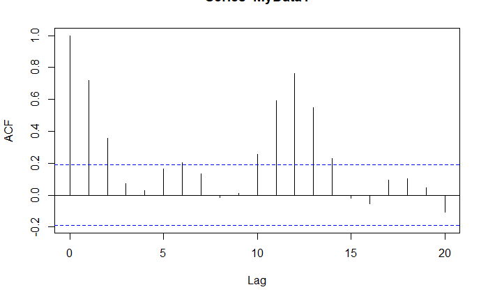

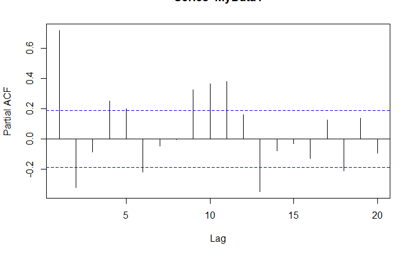

```r
pacf(MyData1)
```

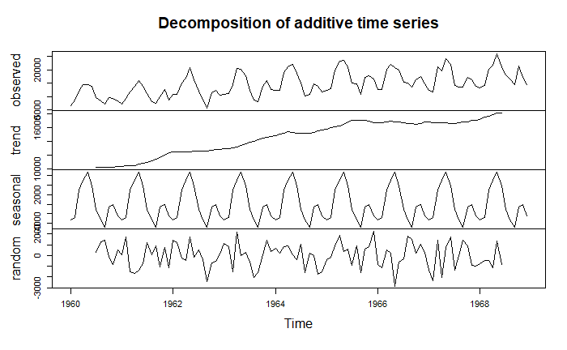

```r
plot(decompose(tsdata1,type = "additive"))
```

I used the decompose function to find the seasonal component , and from the ACF plot, we can see at lag=12, the ACF is very high, so the length of seasonality is 12. From the image, the fluctuation of the sequence grows with the overall level.Seasonally, cars are sold a little more in the summer.

```r
  fit_model1 <- Arima(tsdata1,order=c(1,0,2),seasonal=c(1,1,2),lambda=0)
  summary(fit_model1)
```

```
Series: tsdata1
ARIMA(1,0,2)(1,1,2)[12]
Box Cox transformation: lambda= 0

Coefficients:
         ar1      ma1      ma2     sar1    sma1     sma2
      0.9963  -0.7197  -0.1361  -0.7699  0.2483  -0.5298
s.e.  0.0070   0.0995   0.0964   0.5333  0.5635   0.2878

sigma^2 estimated as 0.01349:  log likelihood=70.33
AIC=-126.66   AICc=-125.39   BIC=-108.71

Training set error measures:
                   ME     RMSE      MAE        MPE     MAPE      MASE       ACF1
Training set 9.354931 1502.209 1150.736 -0.1175816 7.973636 0.7214551 0.06200981
```

```r
fit_model1.residuals <- residuals(fit_model)
shapiro.test(fit_model1.residuals)
```

```
    Shapiro-Wilk normality test

data:  fit_model1.residuals
W = 0.98595, p-value = 0.3176
```

```r
  fit_model <- Arima(tsdata1,order=c(1,1,2),lambda=0)
  summary(fit_model)
```

```
Series: tsdata1
ARIMA(1,1,2)
Box Cox transformation: lambda= 0

Coefficients:
         ar1      ma1      ma2
      0.4456  -0.5835  -0.3298
s.e.  0.1250   0.1151   0.1004

sigma^2 estimated as 0.0462:  log likelihood=13.66
AIC=-19.32   AICc=-18.92   BIC=-8.63

Training set error measures:
                   ME    RMSE     MAE      MPE     MAPE     MASE      ACF1
Training set 721.7876 3017.43 2330.59 1.676636 16.08661 1.461166 0.0475897
```

```r
fit_autochose <- auto.arima(tsdata1,seasonal = TRUE, ic = "aic",D=1)
summary(fit_autochose)
```

```
Series: tsdata1
ARIMA(1,0,1)(0,1,1)[12] with drift

Coefficients:
         ar1      ma1     sma1    drift
      0.7663  -0.5394  -0.5619  83.3957
s.e.  0.1685   0.2208   0.1337  12.8709

sigma^2 estimated as 2328583:  log likelihood=-840.23
AIC=1690.45   AICc=1691.12   BIC=1703.27

Training set error measures:
                   ME     RMSE      MAE        MPE     MAPE      MASE        ACF1
Training set 15.74514 1408.406 1076.439 -0.9011266 7.535356 0.6748744 -0.01349078
```

Based on the RMSE and MAE, our best model in this case is ARIMA(1,0,1)(0,1,1)[12].

```
    Ljung-Box test

data:  Residuals from ARIMA(1,0,1)(0,1,1)[12] with drift
Q* = 26.969, df = 18, p-value = 0.07957

Model df: 4.   Total lags used: 22
```

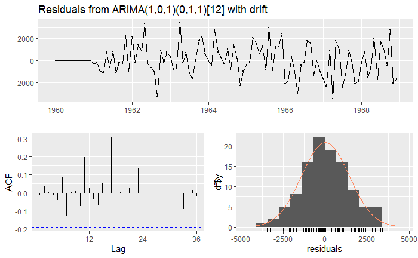

```r
checkresiduals(fit_autochose)
```

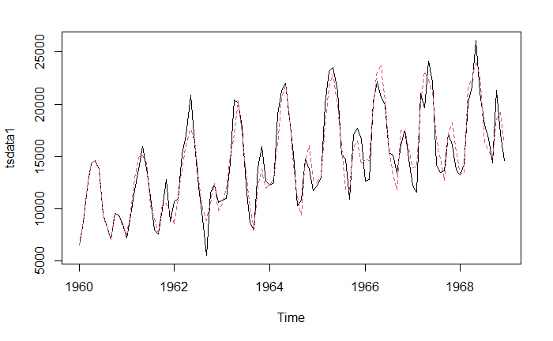

```r
fit_autochose.residuals <- residuals(fit_autochose)
fit_autochose.fitted <- tsdata1 - fit_autochose.residuals
ts.plot(tsdata1)
points(fit_autochose.fitted, type = "l", col = 2, lty = 2)
```

Use the best model to forecast 2 years ahead

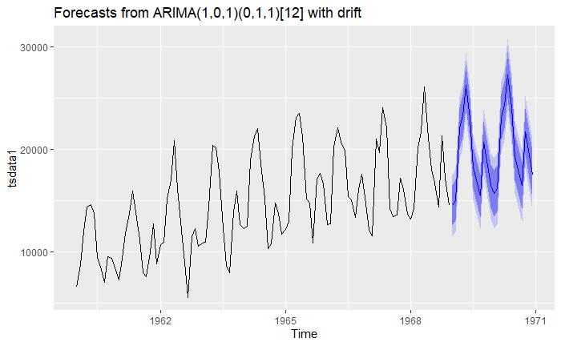

```r
autoplot(forecast(fit_autochose,h=24))
```